# Statistical Inference Project 1

Francisco Martín

October 8, 2018

## Overview

This is the part 1 of the Statistical Inference final project. It consist on a simulation of the exponential distribution using the R function rexp(n,lambda), where lambda is the rate parameter. The mean of exponential distribution is 1/lambda and the standard deviation is also 1/lambda. It will be investigated the distribution of averages of 40 exponentials.

## Analysis

For reproducibility, seed is going to be set arbitrarily at 1994 (because I born on this year). As statement says, lambda = .2, the number of exponentials will be n_exp=40 and the number of samples will be n_sample=1000.

```r
set.seed(1994)
n_exp <- 40
lambda <- .2
n_sample <- 1000
sample <- replicate(n_sample, rexp(n_exp,lambda))
mean_exp <- apply(sample, 2, mean)
```

### Sample mean vs theoretical mean

Once we have our sample ready, we can compare mean agains the theoretical one (1/lambda):

```r
theo_mean <- 1/lambda
sample_mean <- mean(mean_exp)
```

Theoretical mean is 5 and sample mean is 5.0118366. As we can see difference is about 0.2%.

### Sample vs Theoretical: Standard Deviation and Variance

```r
theo_sd <- 1/(lambda*sqrt(n_exp))
theo_var <- ((1/lambda)^2)/n_exp
sample_sd <- sd(mean_exp)
sample_var <- var(mean_exp)
```

### Is the distribution approximately normal?

Finally, this is the question we want to answer. Based on Central Limit Theorem, answer must be yes. Let’s show it.

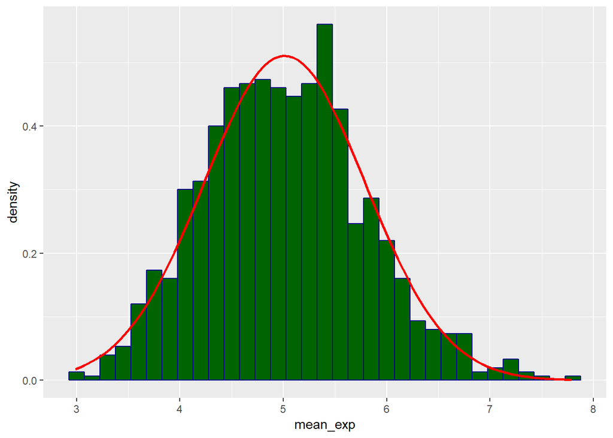

```r
library (ggplot2)
mean_plot <- data.frame(mean_exp)
g <- ggplot(mean_plot, aes(x = mean_exp))
g + geom_histogram(aes (y = ..density..),colour = "dark blue", fill = "dark green", binwidth = .15) +
        stat_function(fun = dnorm, args = list(mean = sample_mean, sd = sample_sd), color = "red", size = 1.0)
```

Red line corresponds to a normal distribution with sample_mean and sample_sd. As we can see, this distribution is approximately normal, in agreement with CLT.